# Personalized Grit Lab Report

Updated March 5, 2021

Hi Audrey,

Welcome to your personalized Grit Lab report!

We will go week by week, reviewing everything you have told us through Poll Everywhere so far.

We hope this will help you reflect on what you learned and experienced during the first half of the lectures of Grit Lab.

Important note!

Sometimes, you may not have been able to respond to all polls.

If the data for one of the polls is missing, the automatic report will display "NA" or "".

Okay, let's get started!

The first half of Grit Lab delves deep into the passion component of Grit.

We like to call it "Choose Easy", because we think gritty people pursue what they enjoy.

Putting it graphically, gritty people tend to pursue the intersection of these four circles.

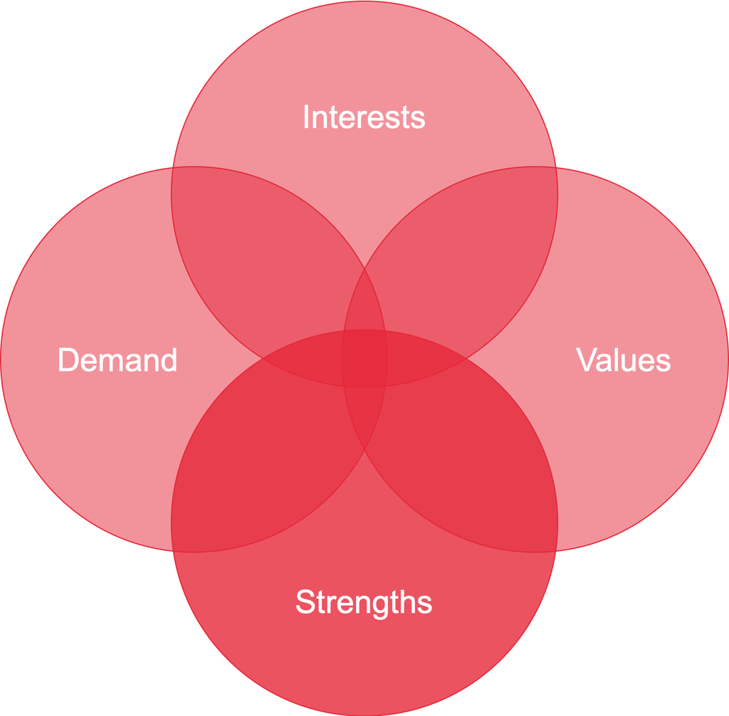

The first time we met, you told us where you were on the grit rubric.

Regarding perseverance you picked Stage 4: Other people would tell you that I hold myself to a standard that is higher than what is explicitly asked of me.

This chart shows how you rated yourself on a 1 - 6 scale.

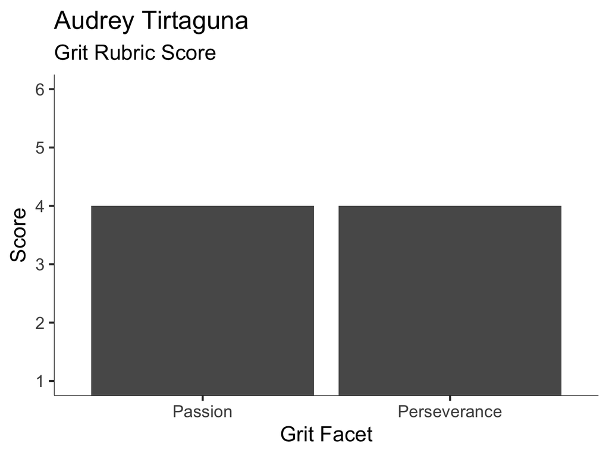

As you know, grit grows, so don’t worry if you are not yet where you’d like to be in your grit development.

Hopefully, this class will help you become grittier each day.

On week 2 we looked at your interests.

Interest is an emotion, and it is the opposite of boredom.

Your interests are the activities or subjects that spontaneously grab your attention.

Trying things out and seeing how you feel is the best way to refine your interests.

Here is the quote you wrote to summarize this class.

""Read to grow your mind, not to ossify it""

On week 3, we studied values, your beliefs about what is important.

You said your top three values were benevolence, universalism, and security.

Here is the quote you wrote to summarize this class.

"Forgiveness"

You wrote a "This I Believe" essay, and here's where you located it on Schwartz’s value taxonomy.

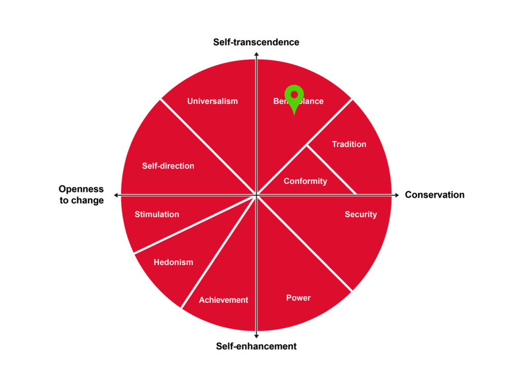

When we talked about strengths on week 4, you said your personality strength was openness.

You said your top three talents were musical, artistic / spatial, and analytic.

Here is the quote you wrote to summarize this class.

"Work as hard as the least talented person"

We then talked about goal hierarchies.

Here's how you said you felt about your top-level goal.

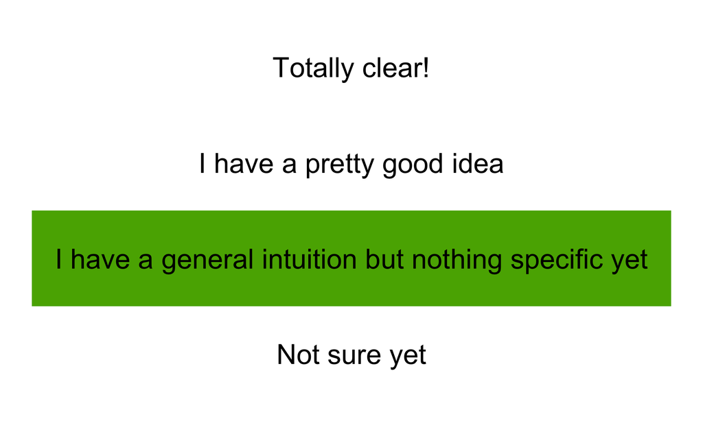

We discussed self-concordance, or how much a goal aligns to your deeply held values and beliefs.

A goal you said you will be pursuing for the next six months is to getting an internship.

Here is how self-concordant that goal was, compared to the rest of the class.

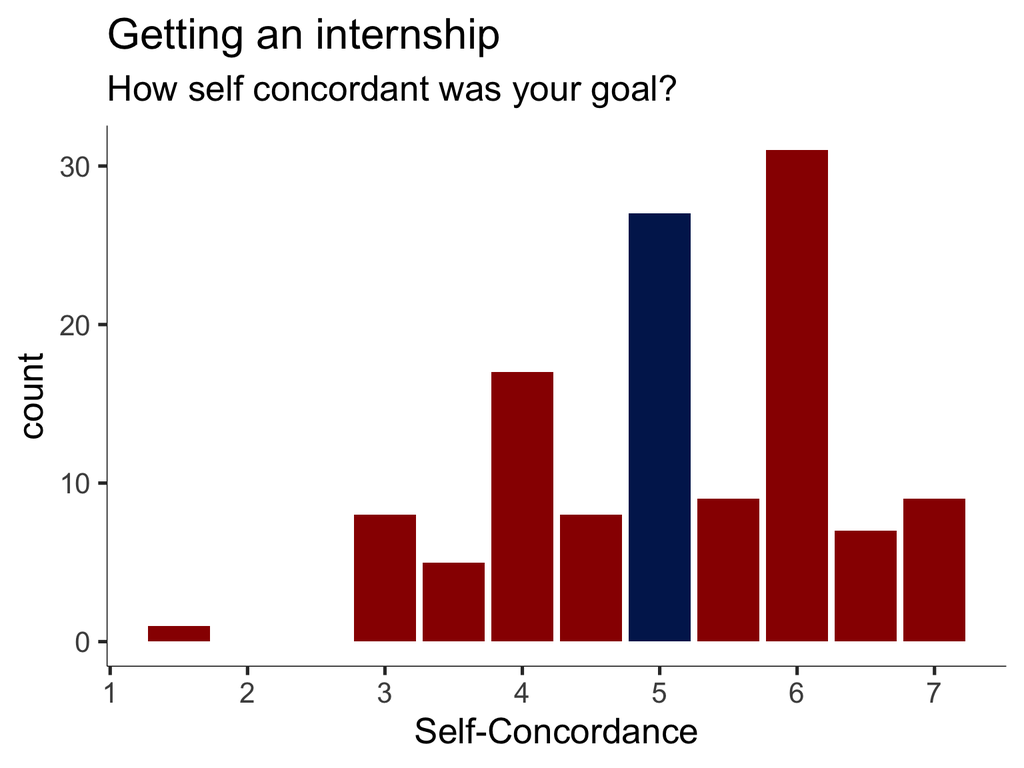

You are in the blue bar!

Don't worry if your self-concordance for that particular goal is low.

It might mean that you need to reframe that goal in a way that makes it more relevant to your deep self, or change it!

Remember that self-concordance is goal specific, so other goals might be more self-concordant.

Here is the quote you wrote to summarize this class.

"Just start"

On week 6 we looked at goal setting and planning.

You learned about the WOOP approach

Wish: What do you want to accomplish. You said:

"Write my sociology 7 pager"

Outcome: What would happen if your wish came true. You said:

"Becoming healthier"

Obstacle: What, that's within you, stands in your way. You said:

"laziness"

Plan: What is your when-then plan to achieve the goal. You said:

"Today after class, I'll go to the gym"

Here is the quote you wrote to summarize this class.

"There is no right answer to life; journey is all that matters, Set feasible goals"

Here's how your mood has been through the semester.

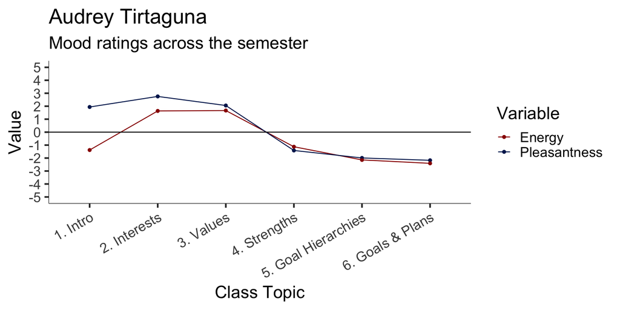

Do you notice any patterns? Is there anything that correlates with your mood?

Here are all the questions you've had throughout the semester.

| Class | Question |
| --- | --- |
| 2. Interests | What happens if your interests lead to unconventional career choices? How to build confidence to make these choices? |
| 4. Strengths | My question before |

Make sure to go to your TA's office hours if you want to talk about these. It'll be fun for both of you.

We hope this has been useful to you!

With grit and gratitude,

Angela and the Grit Lab team.